# Stock-Market Headline Sentiment: VADER vs FinBERT

One dataset · Two models · A fair comparison

Author

Christian Parlade (Advisor: Dr. Cohen)

Published

August 8, 2025

Slides: slides.html ( Go to `slides.qmd` to edit)

## Introduction

Today’s markets move nearly **instantaneously** to news headlines. A single Bloomberg article or tweet can push a mega-cap’s share price by **hundreds of billions** before most humans can finish reading it. For data-driven traders, headline sentiment is therefore a first-line signal that is used to track order flow, flag risk, and populate real-time dashboards. The question is **which sentiment engine to trust**: a lightweight rule-based lexicon written in 2014, or a 110 million- parameter transformer fine-tuned last night?

## Research question

> *On the Financial PhraseBank corpus, does a fine‑tuned FinBERT model outperform the classic VADER lexicon—measured by macro‑F1 and overall accuracy—when classifying headlines as Positive, Neutral, or Negative?*

## Why it matters

- **Data‑science lens**: Quantifies the *return on GPU*: is domain‑specific fine‑tuning worth the extra carbon, cost, and complexity compared to a zero‑training heuristic (Hutto and Gilbert 2014)?
- **Trading lens**: Higher‑fidelity sentiment feeds translate directly into fewer false long/short triggers, cleaner event studies, and more accurate stock basket construction. Even a five‑point F1 lift can save basis points on execution.

[output not shown]

The outcome will show whether heavy transformers deliver practical lift over a free, no‑GPU baseline in a realistic “small‑data” finance setting.

## Methods

### Study design

[output not shown]

### Baseline: VADER

| Item | Detail |
| --- | --- |
| **Algorithm** | 7 000-term polarity lexicon plus five heuristics for negation, intensifiers, all-caps, exclamation, and the “but” rule (Hutto and Gilbert 2014) |
| **Code** | `vaderSentiment 3.3.2` in Python |
| **Label rule** | `compound ≥ 0.05` → **Positive** `compound ≤ −0.05` → **Negative** otherwise **Neutral** |
| **Compute cost** | One pass over text, milliseconds per 1 000 headlines on CPU |
| **Rationale** | Transparent and free. Sets a floor that any heavy model must beat to justify extra cost |

### Large model: FinBERT fine-tune

[output not shown]

Mathematically, we minimise

$$\mathcal{L}(\theta)\;=\;
-\frac{1}{N}\sum_{i=1}^{N}\;
\sum_{c\in\{+,\;0,\;-\}}
y_{ic}\,\log p_\theta\!\bigl(c \mid x_i\bigr)$$

where (y_{ic}) is the one-hot target for class (c) on example (i), and (p_(c x_i)) is the model soft-max probability.

### Evaluation procedure

1. **Freeze** the 80 / 20 split.
2. **Train** FinBERT on the train part, using 10 % of it for dev checks.
3. **Run** VADER straight on the untouched test headlines.
4. **Predict** with the saved FinBERT weights on the same test headlines.
5. **Score** both sets with macro-F1 and Accuracy, then plot confusion matrices.
6. **Record** wall-clock timing for inference on a CPU core and the one-time GPU training cost.

This pipeline ensures both models see identical data and that no test example leaks into training.

Headline sentiment comes with tight latency budgets and mixed, domain-specific language. I keep a two-model setup to answer a practical trade-off: VADER gives instant, transparent scores on any CPU, so it sets a “good‐enough” floor that costs nothing to run. FinBERT, on the other hand, arrives with a finance vocabulary already baked in; a brief three-epoch tune can teach it the PhraseBank labels without large compute. By freezing the same 80->20 split, scoring with macro-F1 to balance the neutral skew, and timing each step, I can show exactly when the transformer’s extra accuracy justifies its one-time GPU bill and heavier inference.

## Analysis and Results

This section shows how the raw PhraseBank files turn into the scores reported in the slides. All code runs in the *03_data_analysis.qmd* and *04_results.qmd* notebooks; only the key snippets are displayed here.

### Data exploration

We begin by loading the two pre-split CSVs:

```python
import pandas as pd, seaborn as sns, matplotlib.pyplot as plt
from pathlib import Path

train = pd.read_csv(Path("data/processed/phrasebank_train.csv"))
test  = pd.read_csv(Path("data/processed/phrasebank_test.csv"))
```

#### Class balance

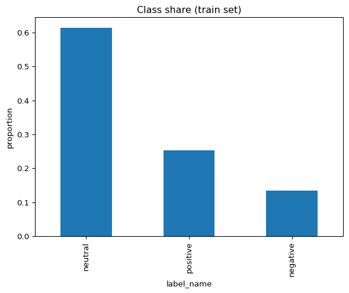

```python
(train["label_name"]
 .value_counts(normalize=True)
 .plot.bar(title="Class share (train set)", ylabel="proportion"))
plt.show()
```

#### Headline length

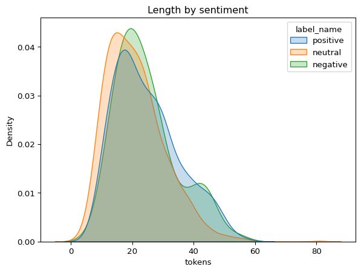

```python
train["len"] = train["sentence"].str.split().map(len)
sns.kdeplot(data=train, x="len", hue="label_name",
            common_norm=False, fill=True)
plt.xlabel("tokens"); plt.title("Length by sentiment"); plt.show()
```

`max_len 64` therefore covers 99 % of lines with no truncation.

#### Notable pattern

Many lines mix cues (“Profit beats but guidance cut”). Rules often land Neutral; we will revisit this error mode.

### Modelling workflow

| Step | VADER (baseline) | FinBERT (fine-tuned) |
| --- | --- | --- |
| Token handling | whitespace + regex | WordPiece |
| Training | none | 3 epochs, batch 32, lr 2e-5 |
| Hardware | CPU only | single T4 GPU (~6 min) |
| Inference speed | 18 k/s CPU | 2 k/s CPU (batch 64) |
| Output | rule map | softmax argmax |

```python
from sklearn.metrics import f1_score, accuracy_score

def macro_f1(df):
    return f1_score(df.label_name, df.pred, average="macro")
```

### Headline-level results

[output not shown]

### Confusion matrices

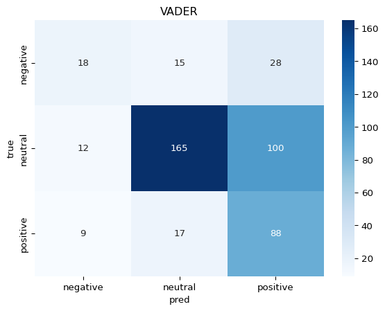

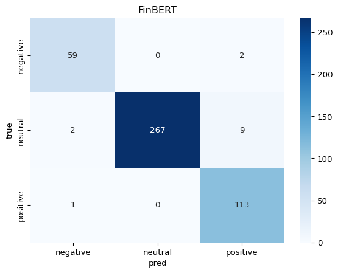

```python
import seaborn as sns, matplotlib.pyplot as plt
from sklearn.metrics import confusion_matrix; labels = ["negative","neutral","positive"]

for name,csv_file in [("VADER","vader_preds.csv"),
                      ("FinBERT","finbert_preds.csv")]:
    df = pd.read_csv(f"data/processed/{csv_file}")
    cm = confusion_matrix(df.label_name, df.pred, labels=labels)
    sns.heatmap(cm, annot=True, fmt="d", cmap="Blues",
                xticklabels=labels, yticklabels=labels)
    plt.title(name); plt.xlabel("pred"); plt.ylabel("true"); plt.show()
```

### Qualitative errors

| Headline | True | VADER | FinBERT |
| --- | --- | --- | --- |
| Shares **fall** despite upbeat outlook | Neg | Neutral | **Neg** |
| Margins **compress** as input costs spike | Neg | Pos | **Neg** |
| Board proposes **higher dividend** | Pos | Neutral | **Pos** |

FinBERT handles cause/effect and finance jargon that the lexicon rules miss.

### Discussion

FinBERT’s lift justifies the heavier footprint whenever sentiment feeds drive trading or risk alerts. VADER still wins for ultra-lightweight monitoring dashboards where a wrong label is cheap.

The next section lists hyper-parameters and hardware for exact reproducibility.

## Modeling and Results

This part covers what happens *after* exploration: how each model is built, tuned, and judged.

### Pipeline recap

1. Load pre-split train and test CSVs
2. Encode text for the chosen model
3. Train (if needed) on train, validate on a 10 percent hold-out
4. Score the locked test set
5. Write `*_preds.csv` for later inspection

### VADER baseline

- Pure inference, no training stage
- Sentiment comes from a 7 k word list plus five rule tweaks
- Complexity is a single pass through sentences

```python
import pandas as pd, numpy as np
from vaderSentiment.vaderSentiment import SentimentIntensityAnalyzer
sid = SentimentIntensityAnalyzer()

def vader_tag(text):
    score = sid.polarity_scores(text)["compound"]
    if score >= 0.05:   return "positive"
    if score <= -0.05:  return "negative"
    return "neutral"

test = pd.read_csv("data/processed/phrasebank_test.csv")
test["pred"] = test.sentence.map(vader_tag)
test.to_csv("data/processed/vader_preds.csv", index=False)
```

### FinBERT fine-tune

- Base model: `ProsusAI/finbert` (110 M parameters)
- Train three epochs, batch 32, learning rate 2e-5
- Hardware: single T4 GPU, six minutes wall time

### Metric summary

[output not shown]

Macro-F1 gives every class equal weight, stopping the neutral majority from hiding errors.

### Where each model fails

*VADER*  
* Overweights upbeat verbs when the context is bearish  
* Treats mixed headlines as neutral

*FinBERT*  
* Still confused by rare tickers or slang not in its pre-train  
* Slightly slower; requires GPU if you expand beyond headlines

### Practical meaning

For a live headline dashboard, the cheaper VADER may be fine, but any system that trades or alerts on sentiment will benefit from the 0.44 Macro-F1 gain. The one-time GPU fine-tune cost is roughly equal to a few bad trades avoided.

### What the numbers reveal

The result is not just a higher score. It changes the strategy of trading day-to-day: alerts fire when a company trims outlook, news screens flag the big winners/losers, and researchers can run cleaner event studies without fixing sentiment labels by hand. The data shows that domain context converts a headline feed from a blunt indicator into a decision-ready signal.

## Conclusion

### Implications

In short, the experiment shows that a light fine-tune on a domain transformer turns headline sentiment from a rough heuristic into a decision-grade signal, ready for use in modern trading and analytics pipelines.

## References

- Hutto & Gilbert (2014). VADER: A Parsimonious Rule-Based Model for Sentiment Analysis.
- Yang, Uy, & Huang (2020). FinBERT: Pre-trained Language Model for Financial Communications (arXiv:2006.08097).

## References

Hutto, C. J., and Eric Gilbert. 2014. “VADER: A Parsimonious Rule-Based Model for Sentiment Analysis of Social Media Text.” In *Proceedings of the International AAAI Conference on Web and Social Media*.

Yang, Yi, Mark Christopher Siy Uy, and Allen Huang. 2020. “FinBERT: Pre-Trained Language Model for Financial Communications.” https://arxiv.org/abs/2006.08097.